# NYPD Shooting Data Report

Wyatt M

2024-02-26

```r
library(tidyverse)
# in case we do anything with random variables
set.seed(42)
```

## Importing Data

To import the data, I did exactly as in the video but using the “NYDP Shooting Incident Data (Historic)” csv. I set a variable to be the required [download url](https://data.cityofnewyork.us/api/views/833y-fsy8/rows.csv?accessType=DOWNLOAD) and used the “read.csv()” function to call that variable and now have the csv stored as a table.

### Data Description

“List of every shooting incident that occurred in NYC going back to 2006 through the end of the previous calendar year.”

```r
# importing data
nypd_data_url <- "https://data.cityofnewyork.us/api/views/833y-fsy8/rows.csv?accessType=DOWNLOAD"
nypd_csv <- read.csv(nypd_data_url)

nypd_csv[sample(nrow(nypd_csv),3),]
```

```
##       INCIDENT_KEY OCCUR_DATE OCCUR_TIME      BORO LOC_OF_OCCUR_DESC PRECINCT
## 27185    260491291 12/24/2022   03:30:00 MANHATTAN            INSIDE       34
## 18753     77264275 02/13/2011   20:10:00  BROOKLYN                         79
## 21657     85065261 06/02/2012   22:42:00  BROOKLYN                         83
##       JURISDICTION_CODE LOC_CLASSFCTN_DESC    LOCATION_DESC
## 27185                 0         COMMERCIAL RESTAURANT/DINER
## 18753                 0
## 21657                 0
##       STATISTICAL_MURDER_FLAG PERP_AGE_GROUP PERP_SEX PERP_RACE VIC_AGE_GROUP
## 27185                   false         (null)   (null)    (null)         25-44
## 18753                   false                                           18-24
## 21657                   false                                           18-24
##       VIC_SEX       VIC_RACE X_COORD_CD Y_COORD_CD Latitude Longitude
## 27185       M WHITE HISPANIC    1006604     254113 40.86413 -73.91918
## 18753       M          BLACK     998822     189420 40.68659 -73.94746
## 21657       M WHITE HISPANIC    1010421     187901 40.68239 -73.90564
##                                             Lon_Lat
## 27185                  POINT (-73.919179 40.864128)
## 18753 POINT (-73.94745878399993 40.686587133000046)
## 21657  POINT (-73.90564187499996 40.68239113100003)
```

## Tidying Up

For this data to be useful it needs to be cleaned up a little and have data types reformatted. The first step will be to set the date and times to not be char sets anymore.

```r
# reformat
nypd_df <- mutate(nypd_csv, OCCUR_DATE = mdy(OCCUR_DATE))
nypd_df <- mutate(nypd_df,  OCCUR_TIME = hms(OCCUR_TIME))

# drop not needed columns
drop <- c("PRECINCT","X_COORD_CD","Y_COORD_CD","Latitude","Longitude","Lon_Lat")
nypd_df <- nypd_df[,!(names(nypd_df) %in% drop)]
```

## Visualizing

Now we have the data cleaned up and reformatted, I want to look into which Boroughs had the highest perpetrator rates along with segregating by sex. This will allow us to see the difference not only between the different boroughs but also who is more likely to commit and act of violence with a firearm based on sex.

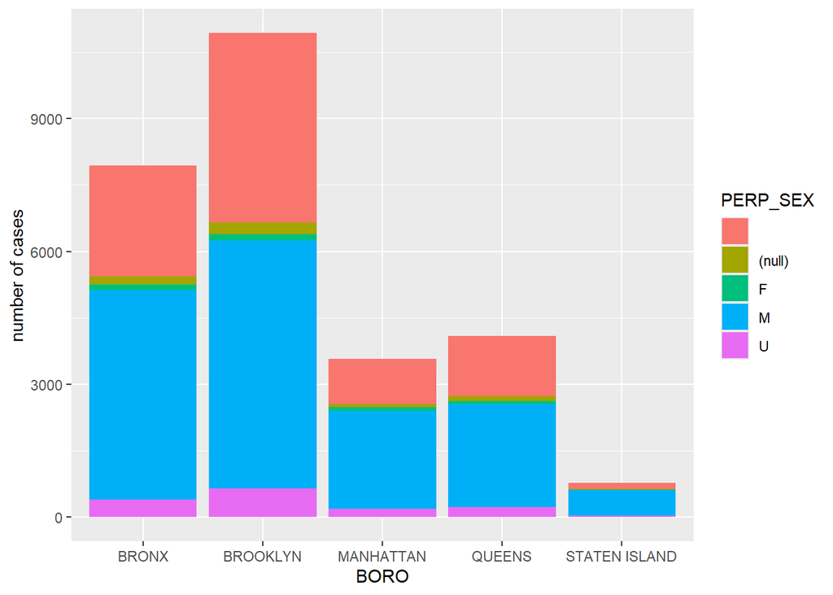

```r
# ggplot a bar graph
ggplot(nypd_df, aes(fill=PERP_SEX, x=BORO)) +
  geom_bar()+
  ylab('number of cases')
```

### Further Tidying

Due to how much incomplete data there is in the table, we should clean up the empty and null values so it doesn’t clutter the data.

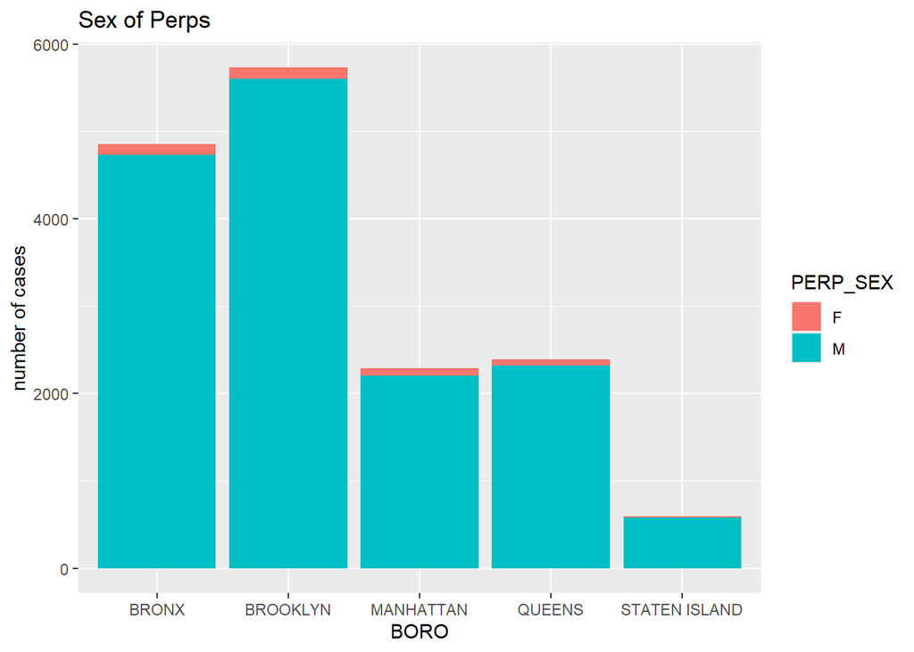

```r
# drop rows where sex is not M or F
nypd_perp_sex_df <- nypd_df[nypd_df$PERP_SEX %in% c("M","F"),]

# now re-plot the graph
ggplot(nypd_perp_sex_df, aes(fill=PERP_SEX, x=BORO)) +
  geom_bar()+
  ylab('number of cases')+
  labs(title = 'Sex of Perps')
```

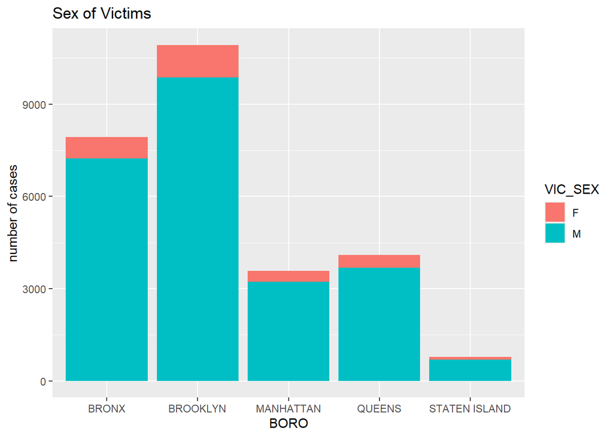

```r
# drop rows where sex is not M or F
nypd_vic_sex_df <- nypd_df[nypd_df$VIC_SEX %in% c("M","F"),]

# now re-plot the graph
ggplot(nypd_vic_sex_df, aes(fill=VIC_SEX, x=BORO)) +
  geom_bar()+
  ylab('number of cases')+
  labs(title = 'Sex of Victims')
```

## When Did These Occur?

For this section I would like to look into what months these incidents occurred. Maybe there are indicators that there are just months where people feel more or less violent during the year.

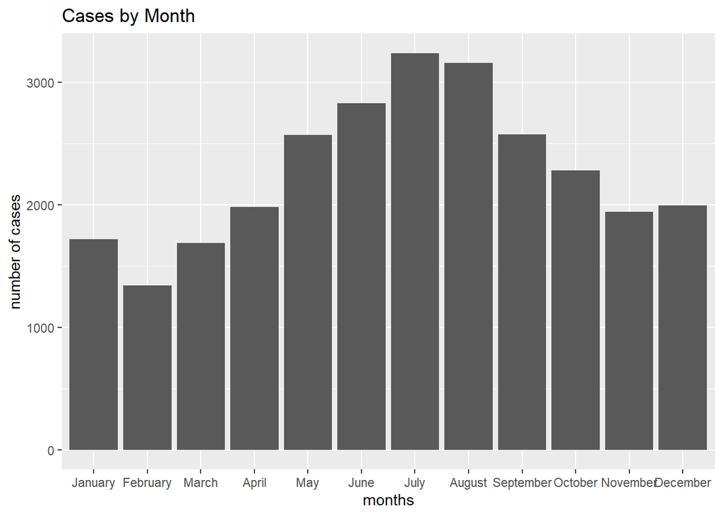

```r
# using the more raw df without the removal of unknown sex of perp
# also set months in order
ordered_df <- nypd_csv[order(as.Date(nypd_csv$OCCUR_DATE, format="%m/%d/%Y")), ]
# now properly format the dates
ordered_df <- mutate(ordered_df, OCCUR_DATE = mdy(OCCUR_DATE))

# plot the graph with the in order dates
ggplot(ordered_df, aes( x=fct_inorder(months(OCCUR_DATE)))) +
  geom_bar() +
  xlab('months')+
  ylab('number of cases')+
  labs(title = 'Cases by Month')
```

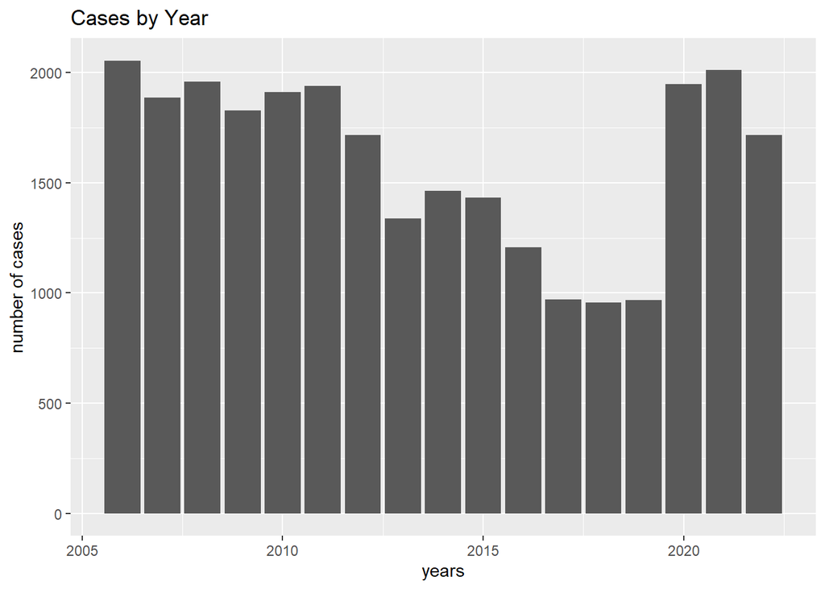

```r
ordered_df <- nypd_csv[order(as.Date(nypd_csv$OCCUR_DATE, format="%m/%d/%Y")), ]
# now properly format the dates
ordered_df <- mutate(ordered_df, OCCUR_DATE = mdy(OCCUR_DATE))

ggplot(ordered_df, aes( x=year(OCCUR_DATE))) +
  geom_bar() +
  xlab('years')+
  ylab('number of cases')+
  labs(title = 'Cases by Year')
```